# Tree Based Classification/ Model Validation

Parash Upreti

July 11, 2016

### Summary of this document

- Exploring dataset avaialbe in R -Iris data exploration
- Decision Tree Algorithm . -Using rPart and Ctree packags
- Cross Validations and testing hypothesis statistically

### Exploring the iris data set.

Iris dataset is preloaded in R

```r
attach(iris)
head(iris)
```

```
##   Sepal.Length Sepal.Width Petal.Length Petal.Width Species
## 1          5.1         3.5          1.4         0.2  setosa
## 2          4.9         3.0          1.4         0.2  setosa
## 3          4.7         3.2          1.3         0.2  setosa
## 4          4.6         3.1          1.5         0.2  setosa
## 5          5.0         3.6          1.4         0.2  setosa
## 6          5.4         3.9          1.7         0.4  setosa
```

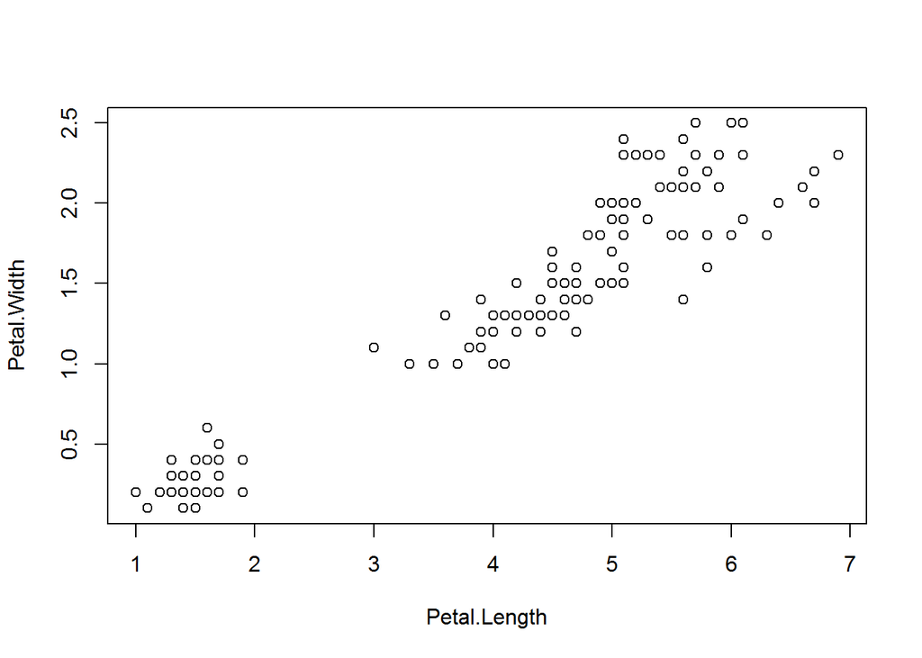

```r
plot(Petal.Length,Petal.Width)
```

Additional options in basic R polt

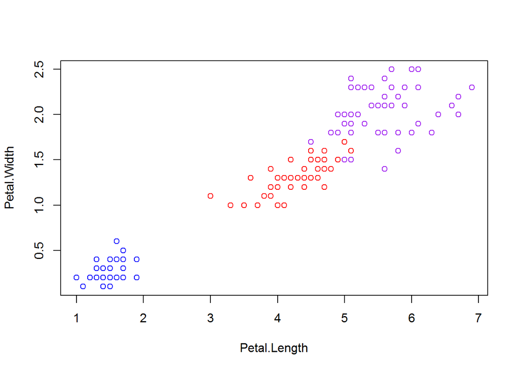

```r
plot(Petal.Length,Petal.Width,col=c('blue','red','purple')[Species])
```

## Decision trees with the rpart package.

Decision tree is a tree based algorithm for classification and regression problems.

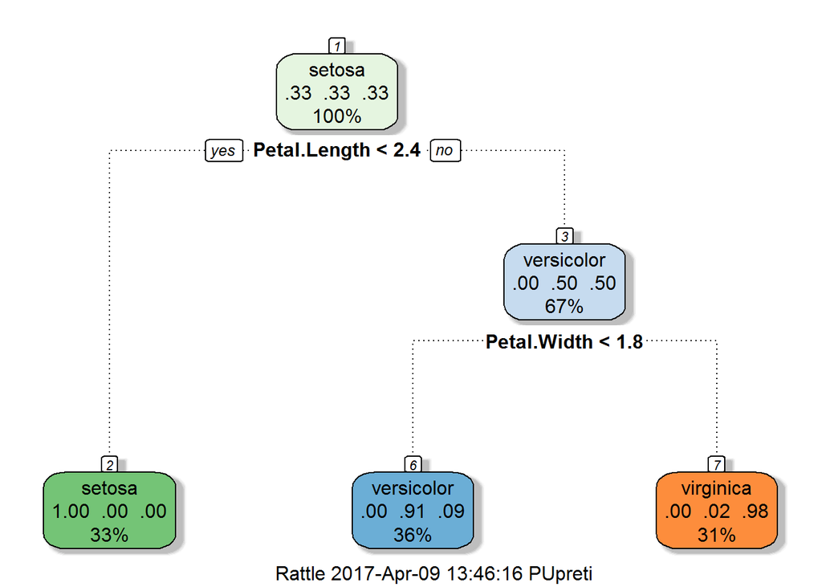

```r
#also need to install package rpart.plot
library(rpart)
library(rattle)
library(RColorBrewer)

iristree=rpart(Species~Sepal.Length+Sepal.Width+Petal.Length+Petal.Width,  data=iris)
iristree=rpart(Species~.,data=iris)

fancyRpartPlot(iristree)
```

Confusion matrix can be used to test how well the classification worked based on the algorithm.

```r
predSpecies=predict(iristree,newdata=iris,type="class")
confusionmatrix=table(Species,predSpecies)

#confmatrix function
confmatrix=function(y,predy){
  matrix=table(y,predy)
  accuracy=sum(diag(matrix))/sum(matrix)
  return(list(matrix=matrix,accuracy=accuracy,error=1-accuracy))
}
```

A second look at the iris scatterplot.

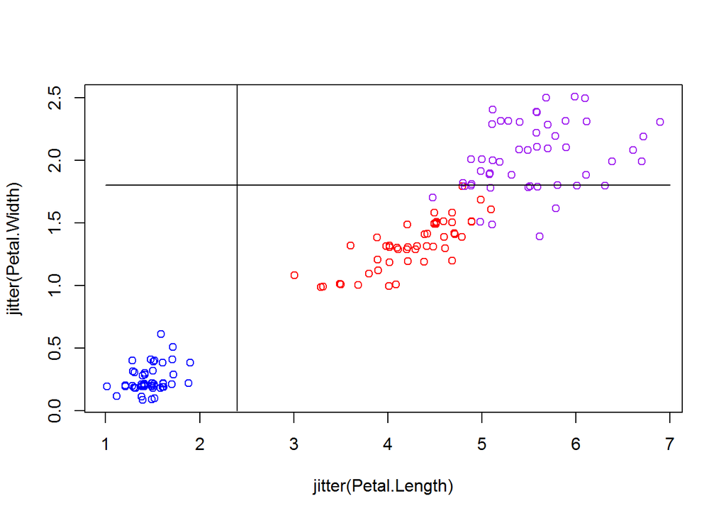

```r
plot(jitter(Petal.Length),jitter(Petal.Width),col=c('blue','red','purple')[Species])
lines(1:7,rep(1.8,7),col='black')
lines(rep(2.4,4),0:3,col='black')
```

Accuracy for rpart tree.

Accuracy for a model can be tested by looking at the true output value against the predicted value.

The confusion matrix function above calculates accuracy for the decision tree prediction.

[output not shown]

```r
confmatrix(iris$Species,
           predict(iristree,newdata=iris,type="class"))
```

```
## $matrix
##             predy
## y            setosa versicolor virginica
##   setosa         50          0         0
##   versicolor      0         49         1
##   virginica       0          5        45
##
## $accuracy
## [1] 0.96
##
## $error
## [1] 0.04
```

The party package.

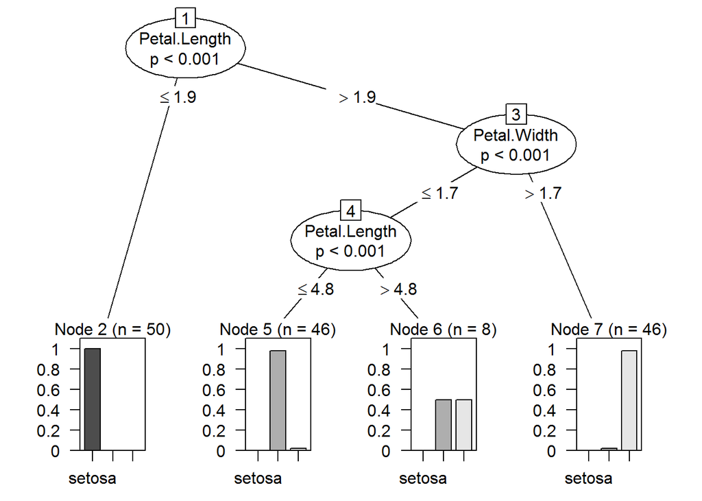

```r
library(party)
iristree2=ctree(Species~.,data=iris)
plot(iristree2)
```

Simple plot of decision tree using `ctree` .

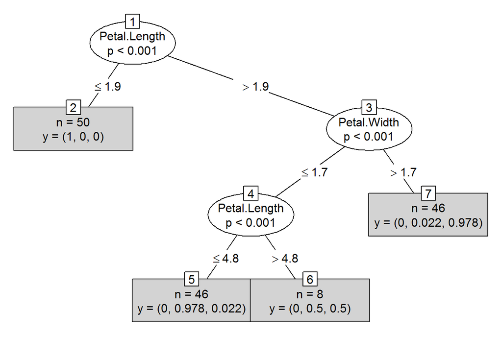

```r
plot(iristree2,type='simple')
```

```r
#ctree confusion matrix.
predSpecies=predict(iristree2,newdata=iris)
confmatrix(Species,predSpecies)
```

```
## $matrix
##             predy
## y            setosa versicolor virginica
##   setosa         50          0         0
##   versicolor      0         49         1
##   virginica       0          5        45
##
## $accuracy
## [1] 0.96
##
## $error
## [1] 0.04
```

Controling the depth of the tree.

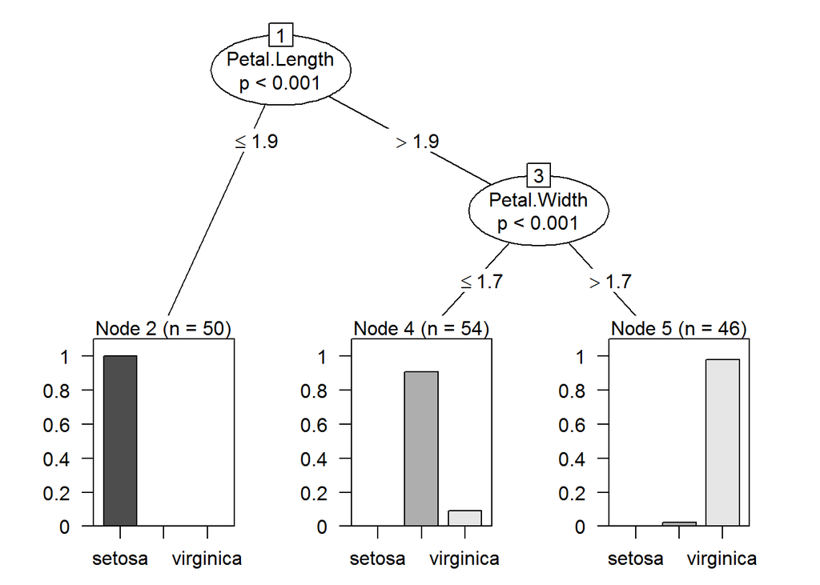

```r
iristree3=ctree(Species~.,data=iris, controls=ctree_control(maxdepth=2))
plot(iristree3)
```

# Training and Testing Sets for Iris Data

```r
set.seed(1120)
train=sample(150,105)
iris[train,]    #Training data  (70% of the data)
iris[-train,]   #Test data      (30% of the data)

#More general code for training set
train=sample(nrow(iris),round(0.7*nrow(iris),0))
```

Use training data to construct a tree.

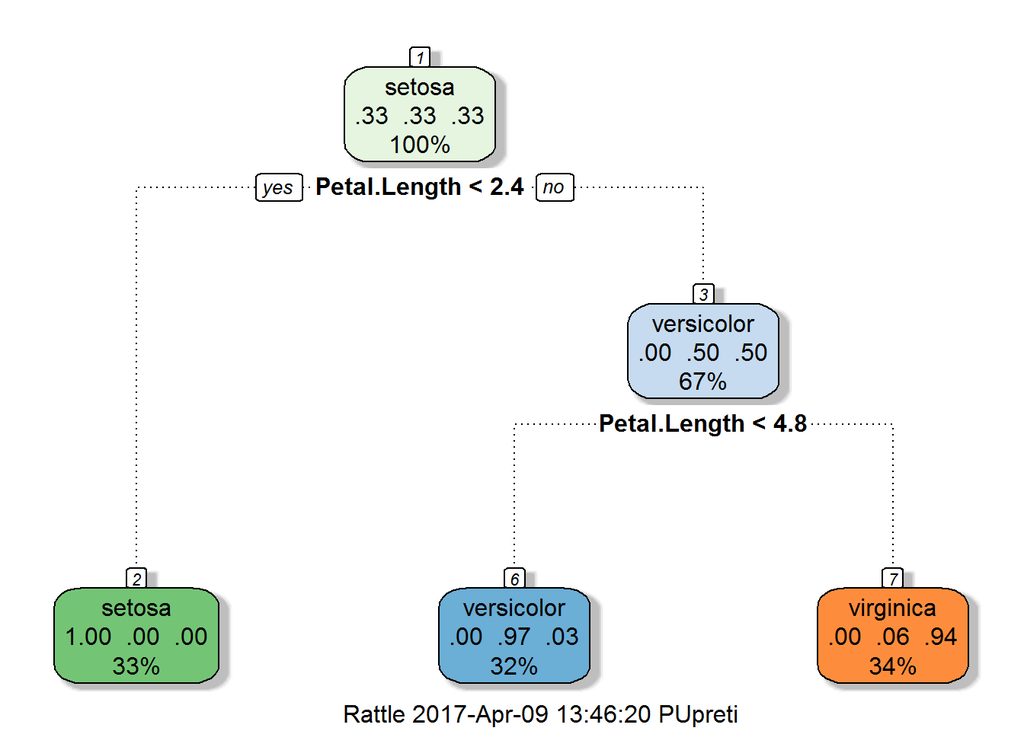

```r
iristree=rpart(Species~.,data=iris[train,])
fancyRpartPlot(iristree)
```

Using confmatrix function to calculate accuracy and error

```r
#Confusion matrix, accuracy, and error rate for training data.
confmatrix(iris$Species[train],
           predict(iristree,newdata=iris[train,],type="class"))
```

```
## $matrix
##             predy
## y            setosa versicolor virginica
##   setosa         35          0         0
##   versicolor      0         33         2
##   virginica       0          1        34
##
## $accuracy
## [1] 0.9714286
##
## $error
## [1] 0.02857143
```

```r
#Confusion matrix, accuracy, and error rate for test data.
confmatrix(iris$Species[-train],
           predict(iristree,newdata=iris[-train,],type="class"))
```

```
## $matrix
##             predy
## y            setosa versicolor virginica
##   setosa         15          0         0
##   versicolor      0         11         4
##   virginica       0          0        15
##
## $accuracy
## [1] 0.9111111
##
## $error
## [1] 0.08888889
```

## Example Data

Import traindata.csv and testdata.csv. Make sure class variable is a factor. And quick data exploration.

```r
traindata = read.csv(url("http://faculty.tarleton.edu/crawford/documents/Math5364/traindata.csv"))
testdata = read.csv(url("http://faculty.tarleton.edu/crawford/documents/Math5364/testdata.csv"))
traindata$class=as.factor(traindata$class)
testdata$class=as.factor(testdata$class)

#Quick Data Exploration
dim(traindata)
```

```
## [1] 900   3
```

```r
head(traindata)
```

```
##             x         y class
## 1  4.76295819  9.583156     0
## 2  9.77532792  8.282632     0
## 3  0.05409077 18.185264     0
## 4 16.48119755 16.129525     0
## 5 12.87665297 16.614146     1
## 6  8.61560780  3.930424     1
```

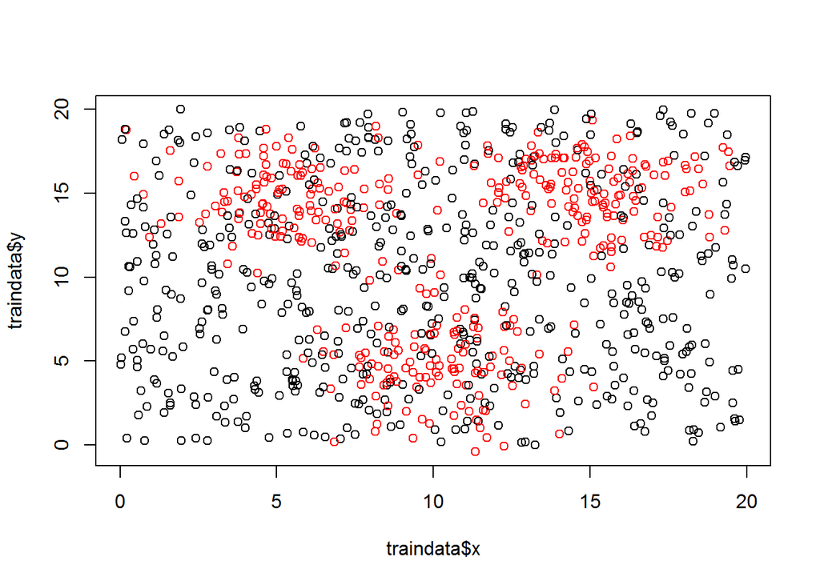

```r
plot(traindata$x,traindata$y,col=traindata$class)
```

```r
dim(testdata)
```

```
## [1] 2100    3
```

```r
head(testdata)
```

```
##            x         y class
## 1 17.9655968  3.183029     0
## 2  6.6738789  6.675273     1
## 3 10.2086342  8.073150     0
## 4  0.7836262  2.630917     0
## 5 13.1109049  7.214607     0
## 6  4.2286522 13.943382     1
```

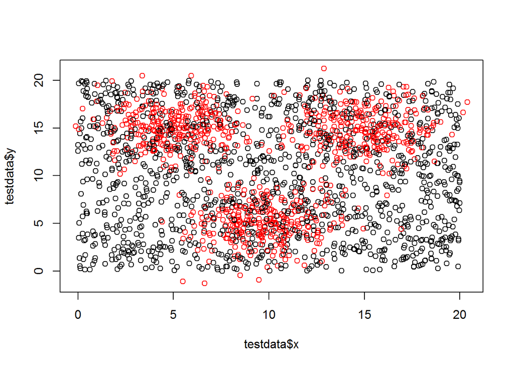

```r
plot(testdata$x,testdata$y,col=testdata$class)
```

Building Tree 1 from the Slides

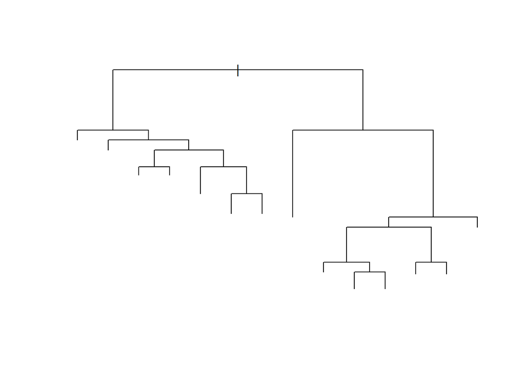

```r
extree1=rpart(class~.,data=traindata)
plot(extree1)
```

```r
confmatrix(traindata$class,predict(extree1,newdata=traindata,type='class'))
```

```
## $matrix
##    predy
## y     0   1
##   0 414 125
##   1  67 294
##
## $accuracy
## [1] 0.7866667
##
## $error
## [1] 0.2133333
```

```r
confmatrix(testdata$class,predict(extree1,newdata=testdata,type='class'))
```

```
## $matrix
##    predy
## y     0   1
##   0 873 388
##   1 224 615
##
## $accuracy
## [1] 0.7085714
##
## $error
## [1] 0.2914286
```

Number of Nodes for Tree 1

```r
#extree1$frame       #Frame of information about the nodes
dim(extree1$frame)  #First entry tells us how many nodes there are
```

```
## [1] 27  9
```

Class Breakdown for Training and Testing Data

```r
prop.table(table(traindata$class))
```

```
##
##         0         1
## 0.5988889 0.4011111
```

```r
prop.table(table(testdata$class))
```

```
##
##         0         1
## 0.6004762 0.3995238
```

```r
nrow(traindata)
```

```
## [1] 900
```

```r
nrow(testdata)
```

```
## [1] 2100
```

## Statistical tests to test the model

### Confidence Intervals for Classification Accuracy

Exact binomial test. Example test data had 2100 records, and 1488 were classified correctly. The confidence interval based on the binomial distribution

```r
confmatrix(testdata$class,predict(extree1,newdata=testdata,type='class'))
```

```
## $matrix
##    predy
## y     0   1
##   0 873 388
##   1 224 615
##
## $accuracy
## [1] 0.7085714
##
## $error
## [1] 0.2914286
```

```r
binom.test(1488, 2100) #binom.test(testdata$class[testdata$class==0],nrow(testdata))
```

```
##
##  Exact binomial test
##
## data:  1488 and 2100
## number of successes = 1488, number of trials = 2100, p-value <
## 2.2e-16
## alternative hypothesis: true probability of success is not equal to 0.5
## 95 percent confidence interval:
##  0.6886162 0.7279429
## sample estimates:
## probability of success
##              0.7085714
```

Building tree 2

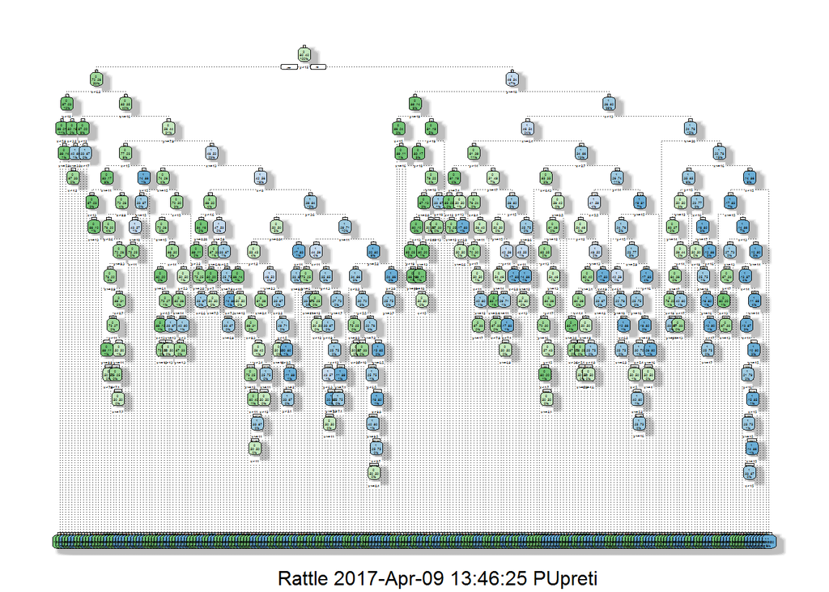

```r
extree2=rpart(class~.,data=traindata,
              control=rpart.control(minsplit=1,cp=0))
fancyRpartPlot(extree2)
```

```r
confmatrix(traindata$class,predict(extree2,newdata=traindata,type='class'))
```

```
## $matrix
##    predy
## y     0   1
##   0 539   0
##   1   0 361
##
## $accuracy
## [1] 1
##
## $error
## [1] 0
```

```r
confmatrix(testdata$class,predict(extree2,newdata=testdata,type='class'))
```

```
## $matrix
##    predy
## y     0   1
##   0 883 378
##   1 338 501
##
## $accuracy
## [1] 0.6590476
##
## $error
## [1] 0.3409524
```

Building accuracy vectors

```r
accvector1=(testdata$class==predict(extree1,newdata=testdata,type='class'))
table(accvector1)
```

```
## accvector1
## FALSE  TRUE
##   612  1488
```

```r
table(accvector1)/2100
```

```
## accvector1
##     FALSE      TRUE
## 0.2914286 0.7085714
```

```r
accvector2=(testdata$class==predict(extree2,newdata=testdata,type='class'))
table(accvector2)
```

```
## accvector2
## FALSE  TRUE
##   716  1384
```

```r
table(accvector2)/2100
```

```
## accvector2
##     FALSE      TRUE
## 0.3409524 0.6590476
```

McNemar Table

```r
mcnemartable=table(accvector1,accvector2)
mcnemartable
```

```
##           accvector2
## accvector1 FALSE TRUE
##      FALSE   438  174
##      TRUE    278 1210
```

Chi-square statistic and p-value

```r
chisq=(abs(174-278)-1)^2/(174+278)
chisq
```

```
## [1] 23.47124
```

```r
pchisq(chisq,df=1,lower.tail=FALSE)
```

```
## [1] 1.267952e-06
```

Built-in Function

```r
mcnemar.test(mcnemartable)
```

```
##
##  McNemar's Chi-squared test with continuity correction
##
## data:  mcnemartable
## McNemar's chi-squared = 23.471, df = 1, p-value = 1.268e-06
```

Exact McNemar Test

```r
library(exact2x2)
mcnemar.exact(mcnemartable)
```

```
##
##  Exact McNemar test (with central confidence intervals)
##
## data:  mcnemartable
## b = 174, c = 278, p-value = 1.144e-06
## alternative hypothesis: true odds ratio is not equal to 1
## 95 percent confidence interval:
##  0.5148605 0.7591830
## sample estimates:
## odds ratio
##  0.6258993
```

## 10-fold Cross-validation

Combine traindata and testdata.

```r
library(cvTools)
Exdata=rbind(traindata,testdata)
folds=cvFolds(nrow(Exdata),K=10,type='random')


#createfolds function
createfolds=function(n,K){
  reps=ceiling(n/K)
  folds=sample(rep(1:K,reps))
  return(folds[1:n])
}

#Folds for Exdata
set.seed(5364)
folds=createfolds(nrow(Exdata),10)
```

Accuracy for first fold

```r
temptest=Exdata[folds==1,]
temptrain=Exdata[folds!=1,]

dim(temptest)
```

```
## [1] 300   3
```

```r
dim(temptrain)
```

```
## [1] 2700    3
```

```r
colSums(Exdata[,1:2])
```

```
##        x        y
## 29827.02 31738.17
```

```r
colSums(temptest[,1:2])+colSums(temptrain[,1:2])
```

```
##        x        y
## 29827.02 31738.17
```

```r
temptree=rpart(class~.,data=temptrain)
tempacc=confmatrix(temptest$class,
                   predict(temptree,newdata=temptest,type="class"))$accuracy

tempacc
```

```
## [1] 0.7166667
```

Accuracy for all folds using a loop.

```r
accvector=1:10

for(k in 1:10){
  temptest=Exdata[folds==k,]
  temptrain=Exdata[folds!=k,]

  temptree=rpart(class~.,data=temptrain)
  accvector[k]=confmatrix(temptest$class,
                     predict(temptree,newdata=temptest,type="class"))$accuracy
}

mean(accvector)
```

```
## [1] 0.714
```

Delete-d Hints. Let d=20

`index=sample(nrow(Exdata))` `index[1:20]` `index[21:nrow(Exdata)]`

Bootstrap Hints

`index=sample(nrow(Exdata),replace=TRUE)`